# Mesopelagic fishes as prey to higher trophic level predators –ERDDAP

# Data availability:

All code sourced from ERDDAP database directly, available at: (https://oceanview.pfeg.noaa.gov/erddap/search/index.html?page=1&itemsPerPage=1000&searchFor=SWFSC-CCTD) #data - See Length.Rmd for export of length information from ERDDAP

# To access data:

Access directly from {rerddap}- that is what I have done here - need dataset id from ERDDAP URL e.g.: info(“SWFSC-CCTD”)

There are currently 4 data tables in ERDDAP: Dataset ID: SWFSC-CCTD # food habits data Dataset ID: SWFSC-CCTD_glossary #glossary Dataset ID: SWFSC-CCTD_predator_taxonomy # predator taxonomy Dataset ID: SWFSC-CCTD_prey_taxonomy #prey taxonomy

# Project background:

This project was created by Ily Iglesias (UCSC/NOAA), to quantify the role of mesopelagic organisms as prey to higher trophic level predators within the California Current. Using the “California Current Trophic Database” data, the following code is an analysis to determine what the frequency of occurrence of mesopelagic prey is for a diversity of predators and in so doing highlight the value of Mesopelagic fishes as prey. NOTE: this code includes accessing data and creating all of the frequency of occurance plots however, it omits the mapping component of our project as we included data not publicially available due to specific species sensitivities.

# Data description:

I exported the following data from the ERDDAP server Data description: https://oceanview.pfeg.noaa.gov/cctd/ Data access: https://oceanview.pfeg.noaa.gov/erddap/search/index.html?page=1&itemsPerPage=1000&searchFor=SWFSC-CCTD

food_habits_data: Information on both the predator (collection info, size etc) and the prey it consumed (prey number, volume, etc). Each row corresponds to one prey taxon in a predators stomach (so long as distinct=T is selected, otherwise data will default to size data and have a row for ea individual measured prey item - potentially multiple rows per spp, corresponding to each item it consumed) glossary.txt:“Terms” listed in other tables predator_taxonomy:taxonomic information about each predator spp. prey_taxonomy:taxonomic list of all prey spp. (1660)

#load packages

# Read in data directly from ERDDAP URL

Dataset ID: SWFSC-CCTD # food habits data- this is the majority of our data! Dataset ID: SWFSC-CCTD_glossary #glossary Dataset ID: SWFSC-CCTD_predator_taxonomy # predator taxonomy Dataset ID: SWFSC-CCTD_prey_taxonomy #prey taxonomy

Dataset isn’t on COASTWATCH erddap URL, rather on “oceanview”, so need to update base URL https://oceanview.pfeg.noaa.gov/erddap/tabledap/SWFSC-CCTD.htmlTable…

```r
# Get info about dataset: food habit data
browse("SWFSC-CCTD", url = "https://oceanview.pfeg.noaa.gov/erddap/") #background info on data field, acknowledgements etc

cctd_info <- rerddap::info(datasetid = "SWFSC-CCTD", url = "https://oceanview.pfeg.noaa.gov/erddap/") # load info on dataset
cctd_info  # print list of variables

# select for variables we are interested in: DO NOT include fields for prey size (as this may present format issue):
food_habits_data <- rerddap::tabledap(cctd_info, fields = c("CCTD_Version",
           "data_set",
           "data_source",
           "predator_taxa",
           "data_source_affiliation",
           "collaborator_1",
           "collaborator_1_affiliation",
           "collaborator_2",
           "collaborator_2_affiliation",
           "collaborator_3",
           "collaborator_3_affiliation",
           "includes_prey_size_information",
           "prey_size_subsampled",
           "includes_empty_stomachs_or_blank_scat",
           "collection_id",
           "date",
           "month",
           "day",
           "year",
           "latitude",
           "longitude",
           "region",
           "fishing_depth",
           "bottom_depth",
           "fishing_temp",
           "bottom_temp",
           "surface_temp",
           "method",
           "collection_information_comments",
           "predator_id",
           "predator_common_name",
           "predator_scientific_name",
           "predator_aphia_id",
           "predator_sex",
           "predator_age",
           "predator_maturity",
           "total_length",
           "fork_length",
           "standard_length",
           "dorsal_mantle_length",
           "eye_fork_length",
           "pre_anal_fin_length",
           "unknown_length",
           "predator_weight",
           "prey_contents",
           "predator_information_comments",
           "prey_id",
           "prey_common_name",
           "prey_scientific_name",
           "prey_aphia_id",
           "prey_life_stage",
           "prey_number",
           "prey_number_corrected",
           "prey_weight",
           "prey_volume",
           "prey_composition_comments"), distinct=TRUE)

# Remove records for blank stomachs (prey_contents=="no")- this matches our prey_composition original df
food_habits_data <- food_habits_data |>
  filter(prey_contents!="no") #removes 13,264 records where there were no prey contents
```

NOTE: distinct=TRUE exports the data in the original SQL format (each row corresponds to a given prey taxa summarized per predator) as opposed to if we export size information where each row corresponds to an individual prey item (with multiple rows per taxa corresponding to each measured prey item).

# Read in additional datasets from ERDDAP URL:

Dataset ID: SWFSC-CCTD_glossary #glossary Dataset ID: SWFSC-CCTD_predator_taxonomy # predator taxonomy Dataset ID: SWFSC-CCTD_prey_taxonomy #prey taxonomy

```r
# glossary
cctd_glossary_info <- rerddap::info(datasetid = "SWFSC-CCTD_glossary", url = "https://oceanview.pfeg.noaa.gov/erddap/") # load info on dataset
cctd_glossary_info  # print list of variables
glossary <- rerddap::tabledap(cctd_glossary_info) #load data into df

# predator taxonomy
cctd_pred_tax_info <- rerddap::info(datasetid = "SWFSC-CCTD_predator_taxonomy", url = "https://oceanview.pfeg.noaa.gov/erddap/") # load info on dataset
cctd_pred_tax_info  # print list of variables
predator_taxonomy <- rerddap::tabledap(cctd_pred_tax_info) #load data into df


# prey taxonomy
cctd_prey_tax_info <- rerddap::info(datasetid = "SWFSC-CCTD_prey_taxonomy", url = "https://oceanview.pfeg.noaa.gov/erddap/") # load info on dataset
cctd_prey_tax_info  # print list of variables
prey_taxonomy <- rerddap::tabledap(cctd_prey_tax_info) #load data into df

# reply dataset info:
rm(cctd_glossary_info, cctd_info, cctd_pred_tax_info, cctd_prey_tax_info)
```

# Mesopelagic species of prey fish:

Provided in repository as Meso_fish.csv This is a list of species that we consider to be mesopelagic (although also includes species that extend well into the bathypelagic). Details of this list and how it was created can be found in our publication and supplemental information.

#Read in list of meso spp

```r
meso_fish <- read.csv("Meso_fish.csv", header = T)

meso_fish <- meso_fish |>
             rename(prey_scientific_name= Prey_Sci_Name) # consistency in naming for later joins with ERDDAP col names
```

# Select for mesopelagic prey

- Of ALL the prey found in predator diets df: food_habits_data, which are mesopealgic?
- Create a unique list of all predators that ate mesopelagic fish

```r
# Create a list of scientific names from list of all mesopelagic fish spp (we will select by these spp)
meso_spp <- meso_fish$prey_scientific_name

# From all gut contents (df: prey_composition in erddap food_habits_data) select meso fish spp in guts
prey_composition_meso <- food_habits_data |>
                         filter(prey_scientific_name %in% meso_spp) #select for gut-contents that are mesopelagic

# Create a unique list of predators that have eaten meso fish species -- scientific name
meso_pred_spp <- unique(prey_composition_meso$predator_scientific_name)

meso_pred_spp #print list of mesopelagic predator species (those pred sp that had at least one record of meso fish)

#length(meso_pred_spp)# 36 species of predators
```

# Calculate Frequency of Occurance metric:

We calculate the frequency of occurrence of mesopelagic fishes in predator diet samples as: No. of stomachs with mesopelagic prey/ Total no. of (non-empty) stomachs per spp.

Below we: - Calculate: Total # of stomachs per pred spp with meso prey - Calculate: Total # of stomachs per pred spp (containing all prey items)

NOTE: Each row represents a prey category. Thus, we can’t take a simple n() to calculate the number of stomachs per spp, because multiple rows may represent the same predator if they had multiple mesopelagic spp in their gut thus we need to summarize by Predator_ID (which is an individual predator of a given spp) to get unique # of predators

```r
# Calculate number of stomachs with meso prey per spp (so for each species, how many unique predator IDs?)
stomach_summary_meso <- prey_composition_meso %>% #prey that is mesopelagic
                         group_by(predator_scientific_name)%>% # group by predator spp.
                         summarise(No_stomachs_with_meso= n_distinct(predator_id), .groups = "drop") #how many unique predators per pred taxon


# Calculate number of stomachs for ALL prey per spp (so for each species in the database, how many unique predator IDs?)
stomach_summary_all <- food_habits_data %>% #all prey spp
                      group_by(predator_scientific_name)%>%
                      summarise(No_stomachs_total= n_distinct(predator_id), .groups = "drop")


# Merge together and calculate frequency of occurrence -- all pred spp
FO <- left_join(stomach_summary_meso, stomach_summary_all, by="predator_scientific_name") %>%
        mutate(freq_of_occurance= No_stomachs_with_meso/No_stomachs_total) # calculate FO as # of stomachs with meso over all stomachs per spp

#remove intermediary dfs
rm(stomach_summary_meso, stomach_summary_all)
```

# Plot frequency of occurance of mesopelagic prey- all predator spp

The following plot is a bar plot with the frequency of occurrence values on the Y and predator spp on the X (arranged by highest FO values to lowest). This plot represents those species where mesopelagic fishes were were commonly encountered

NOTE: In the following plots I included ALL records of mesopelagic predation (even those with only one occurrence)

# Another visualization of the above: frequency of occuance of mesopelagic fish prey in predator diets

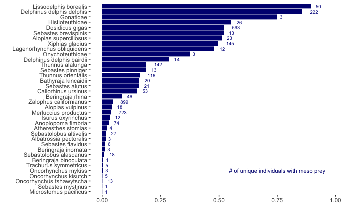

```r
ggplot(data=FO)+
  geom_col(aes(x=reorder(predator_scientific_name, freq_of_occurance), y=freq_of_occurance), fill="navy")+
  geom_text(aes(x=reorder(predator_scientific_name, freq_of_occurance), y=freq_of_occurance, label=No_stomachs_with_meso), size=2.5, hjust=-1, color="darkblue")+
  scale_y_continuous(limits=c(0,1), n.breaks = 5)+ # create more labels on X-axis for values
  annotate(geom = "text", x="Oncorhynchus mykiss", y=0.75, label="# of unique individuals with meso prey", color="navy", size=3)+
  coord_flip()+
  xlab("")+
  ylab("")+
  #xlab("Predator spp")+
  #ylab("FO: Frequency of Occurance (# stomachs with meso prey/total # non-empty stomachs)")+
  theme(panel.background  = element_blank())
```

```r
#ggsave("./plots/FO_sideways.pdf", height = 7, width=10, units = "in")
```

# Compare FO of meso fishes to that of CPS FISH

From page 8-9 of https://www.pcouncil.org/documents/2019/06/cps-fmp-as-amended-through-amendment-17.pdf/ the species to include are:

Stocks managed under the FMP (fisheries managemnt plan):

Pacific sardine Sardinops sagax Pacific (chub) mackerel Scomber japonicus Northern anchovy Engraulis mordax Jack mackerel Trachurus symmetricus

Fisheries ecosystem component species: Pacific herring Clupea pallasii pallasii Jacksmelt Atherinopsis californiensis

```r
# list of coastal pelagic prey (managed and ecosystem component species)

coastal_pelagic_fish <- c("Sardinops sagax", "Scomber japonicus", "Engraulis mordax", "Trachurus symmetricus", "Clupea pallasii pallasii","Atherinopsis californiensis")


# Select for our predator species of interest (all pred spp that ate meso fish)
prey_composition_meso_pred <- food_habits_data %>%
                              filter(predator_scientific_name %in% meso_pred_spp)
```

# Calculate Frequency of Occurance for mesopelagic predators— but for CPS FISH

For a given predator taxa that consumed mesopelagic prey, what is the FO for CPS fish?

```r
# For these predator spp (that ate meso prey at some point) - how many stomachs had Coastal pelagic fish prey?

stomach_summary_cps_fish <- prey_composition_meso_pred %>%
                              filter(prey_scientific_name %in% coastal_pelagic_fish) %>% #select for coastal pel fish spp
                              group_by(predator_scientific_name)%>%
                              summarise(No_stomachs_with_cps_fish=n_distinct(predator_id), .groups = "drop") # number of individual pred per spp


# Merge # pred stomachs with CPS fish to existing FO df and calculate freq of occuance of cps

FO <-  left_join(FO, stomach_summary_cps_fish, by="predator_scientific_name")

FO <- FO |>
    mutate(No_stomachs_with_cps_fish= ifelse(is.na(No_stomachs_with_cps_fish), 0, No_stomachs_with_cps_fish)) |>
    mutate(freq_of_occurance_cps_fish=No_stomachs_with_cps_fish/No_stomachs_total)


#clean up %F calculation info
rm(stomach_summary_cps_fish)
```

NOTE: in case you are wondering why these don’t add up to the total, there are some predators that ate neither mesopelagic prey nor CPS spp (i.e. the predator ate taxa other than mesopelagic fish or CPS) so the total number (and in turn the FO of CPS and Meso won’t necessarily add to 1!)

# Create a plot comparing FO of meso fish to CPS fish

First need to reorder our data so plots in order! flip and create factor for cps and meso

```r
FO_comp_plot <- FO %>%
  select(predator_scientific_name, freq_of_occurance, freq_of_occurance_cps_fish)%>%
  rename(meso=freq_of_occurance, cps_fish=freq_of_occurance_cps_fish)%>%
  pivot_longer(cols = -predator_scientific_name , names_to = "Spp_group", values_to = "FO")%>%
  mutate_all(~replace(., is.na(.), 0)) #replace missing values with zero
```

# PLOT comparison of meso verse cps FISH

Compare FO for meso fish to CPS fish species specifically (note these are only cps fish, not including squid and krill) Also note: we didn’t include CPS fish that were lacking species info (ie if only identified to genus)

```r
# reorder order of predator species to reflect spp with greater meso than cps input
f <- FO %>%
  arrange(freq_of_occurance) # arrange by decreasing FO of meso prey
# vector of order of predator spp by scientific name based on frequency of occurance of meso prey
f <-as.data.frame(f)
pred_order <- f[,"predator_scientific_name"]
print(pred_order)
```

```
 [1] "Microstomus pacificus"      "Sebastes mystinus"          "Oncorhynchus tshawytscha"   "Oncorhynchus kisutch"
 [5] "Oncorhynchus mykiss"        "Trachurus symmetricus"      "Beringraja binoculata"      "Sebastolobus alascanus"
 [9] "Beringraja inornata"        "Sebastes flavidus"          "Albatrossia pectoralis"     "Sebastolobus altivelis"
[13] "Atheresthes stomias"        "Anoplopoma fimbria"         "Isurus oxyrinchus"          "Merluccius productus"
[17] "Alopias vulpinus"           "Zalophus californianus"     "Beringraja rhina"           "Callorhinus ursinus"
[21] "Sebastes alutus"            "Bathyraja kincaidii"        "Thunnus orientalis"         "Sebastes pinniger"
[25] "Thunnus alalunga"           "Delphinus delphis bairdii"  "Onychoteuthidae"            "Lagenorhynchus obliquidens"
[29] "Xiphias gladius"            "Alopias superciliosus"      "Sebastes brevispinis"       "Dosidicus gigas"
[33] "Histioteuthidae"            "Gonatidae"                  "Delphinus delphis delphis"  "Lissodelphis borealis"
```

```
 [1] "Microstomus pacificus"      "Sebastes mystinus"          "Oncorhynchus tshawytscha"   "Oncorhynchus kisutch"
 [5] "Oncorhynchus mykiss"        "Trachurus symmetricus"      "Beringraja binoculata"      "Sebastolobus alascanus"
 [9] "Beringraja inornata"        "Sebastes flavidus"          "Albatrossia pectoralis"     "Sebastolobus altivelis"
[13] "Atheresthes stomias"        "Anoplopoma fimbria"         "Isurus oxyrinchus"          "Merluccius productus"
[17] "Alopias vulpinus"           "Zalophus californianus"     "Beringraja rhina"           "Callorhinus ursinus"
[21] "Sebastes alutus"            "Bathyraja kincaidii"        "Thunnus orientalis"         "Sebastes pinniger"
[25] "Thunnus alalunga"           "Delphinus delphis bairdii"  "Onychoteuthidae"            "Lagenorhynchus obliquidens"
[29] "Xiphias gladius"            "Alopias superciliosus"      "Sebastes brevispinis"       "Dosidicus gigas"
[33] "Histioteuthidae"            "Gonatidae"                  "Delphinus delphis delphis"  "Lissodelphis borealis"
 [1] "Microstomus pacificus"      "Sebastes mystinus"          "Oncorhynchus tshawytscha"   "Oncorhynchus kisutch"
 [5] "Oncorhynchus mykiss"        "Trachurus symmetricus"      "Beringraja binoculata"      "Sebastolobus alascanus"
 [9] "Beringraja inornata"        "Sebastes flavidus"          "Albatrossia pectoralis"     "Sebastolobus altivelis"
[13] "Atheresthes stomias"        "Anoplopoma fimbria"         "Isurus oxyrinchus"          "Merluccius productus"
[17] "Alopias vulpinus"           "Zalophus californianus"     "Beringraja rhina"           "Callorhinus ursinus"
[21] "Sebastes alutus"            "Bathyraja kincaidii"        "Thunnus orientalis"         "Sebastes pinniger"
[25] "Thunnus alalunga"           "Delphinus delphis bairdii"  "Onychoteuthidae"            "Lagenorhynchus obliquidens"
[29] "Xiphias gladius"            "Alopias superciliosus"      "Sebastes brevispinis"       "Dosidicus gigas"
[33] "Histioteuthidae"            "Gonatidae"                  "Delphinus delphis delphis"  "Lissodelphis borealis"
```

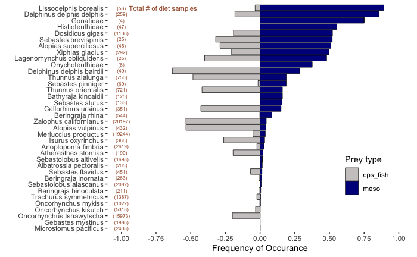

```r
# Change factor level so we plot according to highest percentage of meso FO first
ggplot(data=FO_comp_plot) +
    geom_col(aes(x = factor(predator_scientific_name, levels=print(pred_order)), y = ifelse(Spp_group == "meso", FO, -FO), fill = Spp_group), color="black", size=0.25) +
    geom_text(data=FO, aes(x=predator_scientific_name, y=-1.0, label=paste0("(",No_stomachs_total, ")")), size=2.2, hjust=0.5, color="sienna")+ #add total # of samples per predator taxa
    annotate(geom = "text", x="Lissodelphis borealis", y=-.7, label="Total # of diet samples", color="sienna", size=3)+
  coord_flip()+
    scale_fill_manual(values = c("snow3", "darkblue"))+ #color for cps and meso FO values
    scale_y_continuous(limits=c(-1,1), n.breaks = 9)+ # create more labels on X-axis for values
    #geom_hline(yintercept = 0.25, color="grey", linetype="dashed")+ #add line for those spp with 25% meso
    coord_flip() +
    ylab("Frequency of Occurance")+
    xlab("")+
    labs(fill="Prey type")+ #change legend title
    theme(panel.background = element_blank(),
          legend.position = c(0.85, 0.25))
```

```r
# save plot
#ggsave("./plots/FO_comparison_fish.pdf", width=10, height=7, units="in")

#remove intermediary tables when done
rm(f, FO_comp_plot)
```

# Which pred spp have a greater contribution (FO) from MESO than CCS FISH prey?

```r
# Which spp have greater FO from meso than cps?

 fish<- FO %>%
  mutate(meso=ifelse(freq_of_occurance> freq_of_occurance_cps_fish, 1, 0))%>%
  filter(meso==1)%>% #select for those spp that had greater FO from cps meso than fish
  mutate(FO_cps_fish=round(freq_of_occurance_cps_fish, 3), FO_meso=round(freq_of_occurance, 3)) |> #round the FO values so easier to look at
  rename(samples_meso=No_stomachs_with_meso, samples_cps_fish=No_stomachs_with_cps_fish, samples_total=No_stomachs_total) |> #rename col headers so more straightforward
  select(predator_scientific_name, samples_total, samples_meso, FO_meso, samples_cps_fish, FO_cps_fish) |>   arrange(-FO_meso) #arrange in ascending so highest FO for meso first

fish
```

| predator_scientific_name | samples_total | samples_meso | FO_meso | samples_cps_fish | FO_cps_fish |
| --- | --- | --- | --- | --- | --- |
| Lissodelphis borealis | 56 | 50 | 0.893 | 2 | 0.036 |
| Delphinus delphis delphis | 259 | 222 | 0.857 | 47 | 0.181 |
| Gonatidae | 4 | 3 | 0.750 | 0 | 0.000 |
| Histioteuthidae | 47 | 26 | 0.553 | 0 | 0.000 |
| Dosidicus gigas | 1136 | 593 | 0.522 | 218 | 0.192 |
| Sebastes brevispinis | 25 | 13 | 0.520 | 8 | 0.320 |
| Alopias superciliosus | 45 | 23 | 0.511 | 13 | 0.289 |
| Xiphias gladius | 292 | 145 | 0.497 | 60 | 0.205 |
| Lagenorhynchus obliquidens | 25 | 12 | 0.480 | 10 | 0.400 |
| Onychoteuthidae | 8 | 3 | 0.375 | 0 | 0.000 |

[output cut: 11 more lines]

```r
#write.csv(fish, "FO_meso_vs_cps_fish.csv")
#rm(fish)
```

# Which pred spp have greater than 25% of stomachs with mesofish?!

```r
# Which spp have at least .25 fo of meso fishes (meaning that at least 25% of fish stomachs of a given spp had meso fish?)
over25_FO <- FO |>
  filter(freq_of_occurance>=0.25) |>
  mutate(freq_of_occurance=round(freq_of_occurance, 2)) |>
  arrange(-freq_of_occurance)

# export table
#write.csv(over25_FO, "over25_FO.csv")

#view table
over25_FO
```

| predator_scientific_name | No_stomachs_with_meso | No_stomachs_total | freq_of_occurance | No_stomachs_with_cps_fish | freq_of_occurance_cps_fish |
| --- | --- | --- | --- | --- | --- |
| Lissodelphis borealis | 50 | 56 | 0.89 | 2 | 0.03571429 |
| Delphinus delphis delphis | 222 | 259 | 0.86 | 47 | 0.18146718 |
| Gonatidae | 3 | 4 | 0.75 | 0 | 0.00000000 |
| Histioteuthidae | 26 | 47 | 0.55 | 0 | 0.00000000 |
| Dosidicus gigas | 593 | 1136 | 0.52 | 218 | 0.19190141 |
| Sebastes brevispinis | 13 | 25 | 0.52 | 8 | 0.32000000 |
| Alopias superciliosus | 23 | 45 | 0.51 | 13 | 0.28888889 |
| Xiphias gladius | 145 | 292 | 0.50 | 60 | 0.20547945 |
| Lagenorhynchus obliquidens | 12 | 25 | 0.48 | 10 | 0.40000000 |
| Onychoteuthidae | 3 | 8 | 0.38 | 0 | 0.00000000 |

[output cut: 1 more lines]

```r
rm(over25_FO)
```

# Proportion of all predator species that ate meso spp?

25% of all predator species in the database consumed mesopelagic fish spp (at least once :)

```r
# total number of predator species in the database:
length(unique(predator_taxonomy$predator_scientific_name)) #143 predator taxa
```

```
[1] 143
```

```r
#total number of predators that ate mesopealgic spp
length(unique(prey_composition_meso$predator_scientific_name)) #36
```

```
[1] 36
```

```r
36/143 #25.17%
```

```
[1] 0.2517483
```

# Of the mesopelagic fish prey, who is most commonly consumed?

This is a bit challenging due to the variety of taxonomic resolution within the database (ie family:“myctophid” vs spp: blue lanternfish a type of Myctophid)- so not possible to compare everything at a standard spp level

- Number of occurrences of each prey taxa (ie number of diet samples that each of the spp taxa groups recorded in)..but note this is not equivalent to the total number of stomachs they are found in (ie both myctophid and blue lanternfish may have been in same predator stomach, so need to combine categories to broader taxonomic groups in next step)

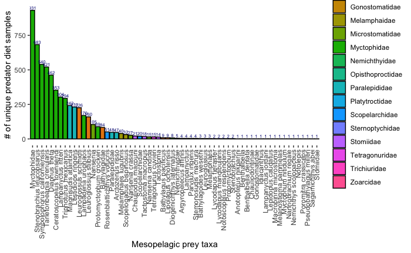

# OF the mesopelagic fish prey, who is most commonly consumed? FAMILY level resolution

Ie instead of mix of spp and higher taxon levels, we can also just look at the higher taxonomic levels (Family): Family makes sense ecologically and because of identification issues in dealing with gut/skat contents. There are a lot of “myctophid spp” in the database already

– I selected for UNIQUE predators so a predator was only counted once if both “myctophid” and “blue lanternfish” occurred in the same predator stomach sample for ex.

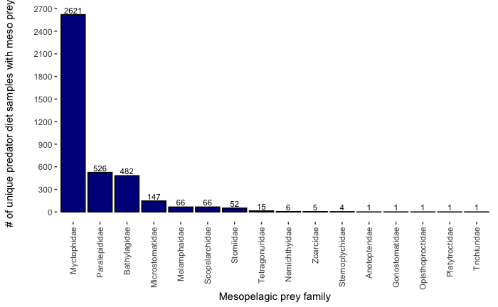

NOTE: count= # of unique stomachs each prey item appeared in (ie total counts equal to total number of diet samples, although could also portray as total records- bc predator could contain multiple items per family per stomach). This also doesn’t mean total number of fish in guts, just total number of unique predator stomachs that each family appeared in.

# What percentage of mesopelagic fishes would be protected with Fishery Management Council Ruling?

I don’t have absolute number of fish, rather the # of predators that consumed given prey taxa, thus the following is: the total # of unique predators that consumed meso fish that would be protected by ruling/ the total # of unique predators that consumed meso fish

https://www.federalregister.gov/documents/2016/04/04/2016-07516/fisheries-off-west-coast-states-comprehensive-ecosystem-based-amendment-1-amendments-to-the-fishery

Based on council language, the following families would receive some protection from future fishing: mesopelagic fishes of the families Myctophidae, Bathylagidae, Paralepididae, and Gonostomatidae;

```r
25/44 # 56.8% of mesopelagic fish identified to species would have been protected
```

```
[1] 0.5681818
```

NOTE That of all the records, I included ALL taxa (regardless of species, genus or family level) but for the percent of actual SPECIES, I first filtered by species….

# OF THE Myctophids

For those Myctophids that were identified to SPECIES, which are most commonly encountered? This doesn’t necessarily mean they are a prefered prey, rather that they are likely more available (abundant)

```r
prey_composition_meso |>
  filter(family=="Myctophidae")
```

[output not shown]

[output not shown]

[output cut: 990 more lines]

# PLOT: Of the identified Myctophids, what percentatge of each species?

This plot takes a sum of all Myctophids that were identified to spp and then determines for each identified myctophid spp, what percentage of the total it represents

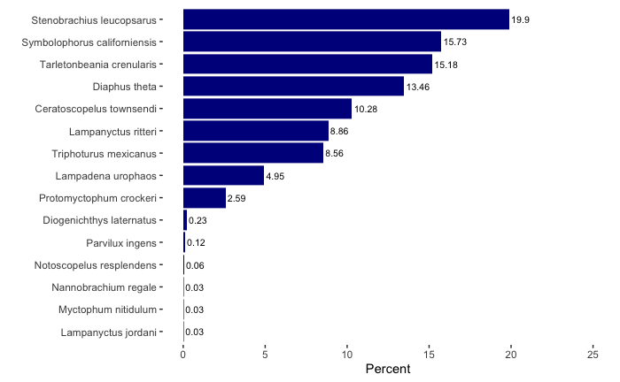

# Who is eating who (which mesopelagic fishes by FAMILY?)

the following code groups prey by family (ex. myctohpidae) and takes a count of which predator spp (based on scientific name) ate fish from a given family NOTE: that I used distinct predator id so count represents unique predator stomachs for a given predator spp

```r
# Calculate the total number of unique pred stomachs with family of meso prey
pred_taxa_prey_fam <- prey_composition_meso |> # all identified prey that was mesopelagic
                group_by(predator_scientific_name, family) |> #group by specific predator taxa and family of prey
                summarize(count_per_family=n_distinct(predator_id), .groups ="drop")

# Calculate the total number of stomachs included (all counts per family) of mesopelagic prey
pred_taxa_prey_fam <-pred_taxa_prey_fam %>%
    group_by(predator_scientific_name) |>  # for each predator taxa
    summarize(family, count_per_family, Total_stomachs_all_fam=sum(count_per_family), .groups = "drop") |>  #calculate total number of stomachs (sum family totals) this is the total of MESO prey not ALL stomachs
    mutate(frac_family_of_meso_stomachs=count_per_family/Total_stomachs_all_fam)#create new column with fraction of all meso prey stomachs per family
# total number of predator taxa that ate mesopealgic fish family (for results section, not plotting)
pred_taxa_prey_fam |>
  group_by(family) |>  #group by mesopelgic fish prey family
  summarize(no_pred= n()) |>  # number of predators per fish family
  arrange(-no_pred)
```

| family | no_pred |
| --- | --- |
| Myctophidae | 32 |
| Bathylagidae | 14 |
| Microstomatidae | 12 |
| Paralepididae | 12 |
| Stomiidae | 7 |
| Melamphaidae | 5 |
| Scopelarchidae | 4 |
| Zoarcidae | 3 |
| Nemichthyidae | 2 |
| Tetragonuridae | 2 |

[output cut: 6 more lines]

NOTE: above, I initially used the No_stomachs_with_meso as my total count to calculate the fraction per family, but because there were instances where an individual predator had more than one family of mesopelagic fish in their guts, this led to a higher number of total stomachs than if we used the No_stomachs_with_meso which only counted a stomach once if it had ANY (ie all family) in guts.

# PLOT which predators are eating which families of fishes?

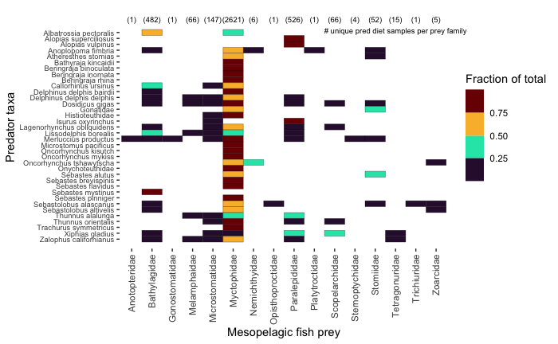

cells represent the fraction of unique predator stomachs with given meso fish family

# Individual predator spp prey?

The next step: For each species/taxa of predator (ie a species that has had any mesopelagic fish in gut…) select for ALL records of that given species and then look at a frequency of occurrence for mesopealgic fish in the guts of that spp. For each predator species, how many diet samples had mesoeplagic fish?

# Mesopelagic taxon (spp and group level) instead of family

| predator_scientific_name | prey_scientific_name | count_per_taxon |
| --- | --- | --- |
| Albatrossia pectoralis | Bathylagidae | 2 |
| Albatrossia pectoralis | Myctophidae | 1 |
| Alopias superciliosus | Lestidiops ringens | 1 |
| Alopias superciliosus | Magnisudis atlantica | 12 |
| Alopias superciliosus | Paralepididae | 11 |
| Alopias vulpinus | Magnisudis atlantica | 16 |
| Alopias vulpinus | Paralepididae | 2 |
| Anoplopoma fimbria | Bathylagidae | 11 |
| Anoplopoma fimbria | Bathylagus pacificus | 4 |
| Anoplopoma fimbria | Chauliodus macouni | 10 |

[output cut: 244 more lines]

# Plot a MAP of the location predators were captured at!

# NOTE:

I am not including code for our maps of the location of predator collection trips because these data contain sensitive information on important predator species.

# Categorize by HABITAT type

# Deal with land-based predator sampling

Note that within the col for “Method” there are the categories: “Stranding” and “Scat Sample” and “” which is just no method recorded

For this analysis, I am assuming that “Scat Sample” are categories correspond to “shore-based” because the recovery of these samples did not occur over a specific ocean bottom depth

- Remove stranding records since we don’t have much idea where these animals were residing when they consumed meso fish Including scat because assuming they came from live animals

```r
# Based on depth values, label as shelf, slope or deep
loc_all <- loc_all %>%
    mutate(habitat = case_when(
    depth>=0& depth<=200 ~ "Shelf",
    depth>200 & depth<=1000 ~ "Slope",
    depth>1000 ~ "Deep"))

#and for those sampling methods on land, convert values to "land" Method either Stranding or Scat
loc_all$habitat <- ifelse(loc_all$method=="Scat Sample", "Land", loc_all$habitat)

# REMOVE STRANDING RECORDS as these are not fair to include since we don't know the depth at which that animal was foragin when alive

loc_all <- loc_all |>
           filter(!method=="Stranding")
```

NOTE: of the scat samples loc_all: California Seal Lion, Northern Fur Seal, Harbor Seal were collected, but only California Seal Lion and Northern Fur Seal consumed meso prey

# Calculate the proportion of each trip that captured mesopelagic (as opposed to non mesopelagic consuming) predators

Jerome had initially suggested that it would be worth plotting the proportion of each collection trip that had mesopelagic predators. In order to accomplish this, I need to calculate the proportion that were mesopelagic/total number of predators per site

Starting df: loc_all (this has all predators and their collection_id) both meso and non-meso predators

Calculation: for each unique collection id (trip), how many predators conumed meso prey

```r
#calculate the total number of predators captured per collection id
pred_trip= loc_all |>
  group_by(collection_id) |>
  summarise(total_pred=n_distinct(predator_id), .groups='drop')

# Calculate the total numer of mesopelagic predators captured per collection id

meso_pred_trip <- loc_all |>
                  filter(prey_scientific_name %in% meso_spp) |> # filter for mesopealgic prey species
                  group_by(collection_id) |> #for each collection trip how many unique meso predators
                  summarize(meso_pred=n_distinct(predator_id), .groups ="drop")


# join our count of total predators and meso predators and calculate the proportion meso
trip_preds <- left_join(pred_trip, meso_pred_trip, by="collection_id") |>
              mutate_all(~replace(., is.na(.), 0)) |>  #replace missing values for meso with 0 for those trips without mesos
              mutate(prop_meso=(meso_pred/total_pred)* 100)

# Add lat lon data from position df to collection id: otherwise each row is individual prey per repeating pred spp
trip_preds <- left_join(trip_preds, position, by="collection_id")

# for each record in trip_preds which is each unique collection trip, and the prop of meso pred per trip, add position info
```

# PLOT proportion of each unique collection trip that caught mesopelagic prey

Would also like to plot this figure with color instead of size to represent proportion for some reason having a tough time using fill option

# PLOT ONLY Mesopelagic predator collections

```r
# Just meso data
p=trip_preds |>
  filter(meso_pred>0)
range(p$prop_meso) #1.75 to 100 % meso

range(p$total_pred) # from 1 to 118 predators collected per trip

# plot of distribution of # of predators per trip
ggplot(data=trip_preds, aes(x=total_pred, group=NA))+
  geom_histogram(color="black", fill="grey" , alpha=0.5)+
  geom_vline(aes(xintercept=mean(total_pred)), color="red")+
  scale_x_continuous(expand = c(0,0), breaks = round(seq(min(trip_preds$total_pred), 100, by = 4),1))+
  scale_y_continuous(expand=c(0,0))+
  theme_few()


# HMMM so there were quite a few collection trips that only caught 1 predator...mean was ~9 predators
```

[output not shown]

# MAP: proportion mesopelagic for those location ids that caught at least one mesopelagic fish

```r
basemap(data=trip_preds, bathymetry = TRUE, legends = F)+
  scale_fill_viridis_d(option="G", direction=-1)+
  geom_spatial_point(data=filter(trip_preds, meso_pred>0), aes(x=Longitude, y=Latitude, color=prop_meso, size=total_pred), shape=21)+
  scale_color_fermenter(palette = 7, direction=1) +#orange scale
  xlab("")+
  ylab("")+
  labs(color="% Meso", size="Total # pred")+
  annotation_scale(location = "tr")+
  annotation_north_arrow(location = "tr", which_north = "true", height = unit(1, "cm"),
  width = unit(1, "cm"), pad_y = unit(0.70, "cm"))+
  theme(panel.grid = element_blank(),
        legend.position = c(0.92,0.52),#actual position of legend
        legend.background = element_rect(fill="transparent"),
        legend.key = element_rect(fill='transparent'),
        #legend.box.background = element_rect(color="black", size=0.5), #black box around legend feature
        legend.box.margin = margin(1, 1, 1, 1), #distance of box around points in legend
        legend.title = element_text(size=7), # the title text
        legend.text=element_text(size=7),
        legend.spacing.y = unit(0.01, 'cm')) #distance between legend items


ggsave("./plots/map_prop_meso.pdf")
```

[output not shown]